# Teardrops on my Data Frames: Topic Modeling of Taylor Swift Songs

2018-07-25

I was browsing Kaggle for an interesting dataset when I ran across a [library of Taylor Swift's songs](https://www.kaggle.com/PromptCloudHQ/taylor-swift-song-lyrics-from-all-the-albums).

Usually when I find data on Kaggle, it's been thoroughly picked over. However, luckily for me, only one person had analyzed these data! Because so few people had looked at these data, I figured I would be able to make a meaninfgul contribution to the discussion.

My running theory for the past decade is that Taylor's songs all sound the same. This belief has gotten me into more than a few arguments with friends. Would the data prove me right?

Speficially, this analysis seeks to answer the following questions:

1. Did the length of Taylor's songs change over time?
2. Did the complexity of songs change over time?
3. Do Taylor's songs generally cover a few topics? If so, how might we charcterize those topics?
4. Does a trend exist between song topic and song year released?

The data needs pre-processing, which includes removing stopwords and special characters and coercing every word to lowercase. Removing stopwords is a typical natural language processing task, but it gives me some anxiety because some of Taylor's most prominent songs (such as "You Belong With Me") contain stopwords ("You", "With", and "Me").

## Question 1: Visualizing song length over time

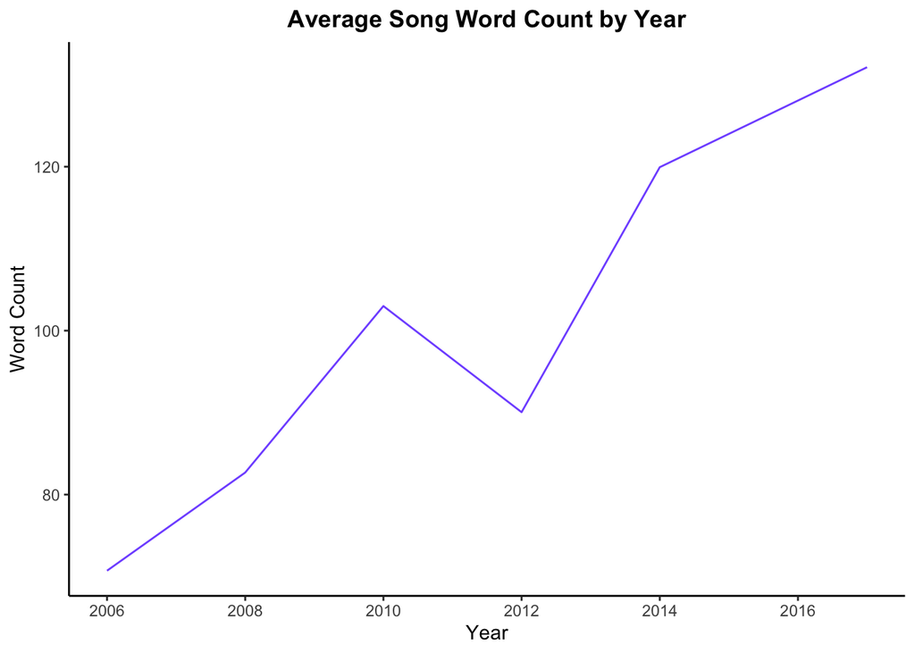

This chart does not account for within-year variation. It's entirely possible that a few songs had high especially high or low word counts. Looking at the entire distribution of word counts across songs in a given album would be more informative. Let's look at that within-year variation.

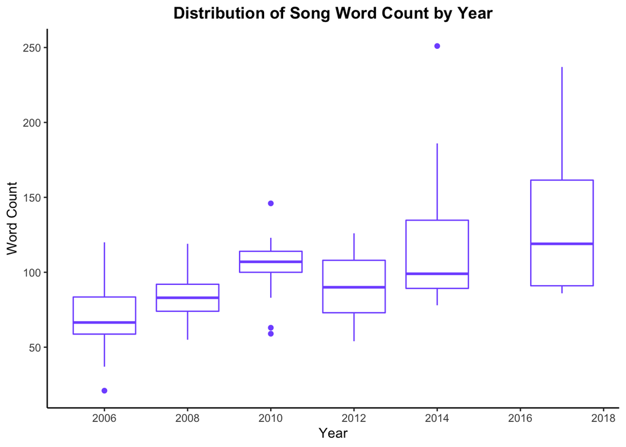

The distribution of word counts by song becomes more spread out over the years. Interestingly, small word-count songs have higher word counts as time goes on as well. This trend suggests that the widening distributions are driven by greater wordiness and not a greater spread over word count length. Taylor released her wordiest songs in 2017. Is this trend a sign that Taylor's songs are getting more intricate or complex over time?

## Question 2: Visualizing song complexity over time

I define "song conplexity" as the number of unique non-stopword words per song. I look at song complexity from two different angles:

1. On average, how many unique words appear per song per year?
2. On average, how many times is a word repeated per song?

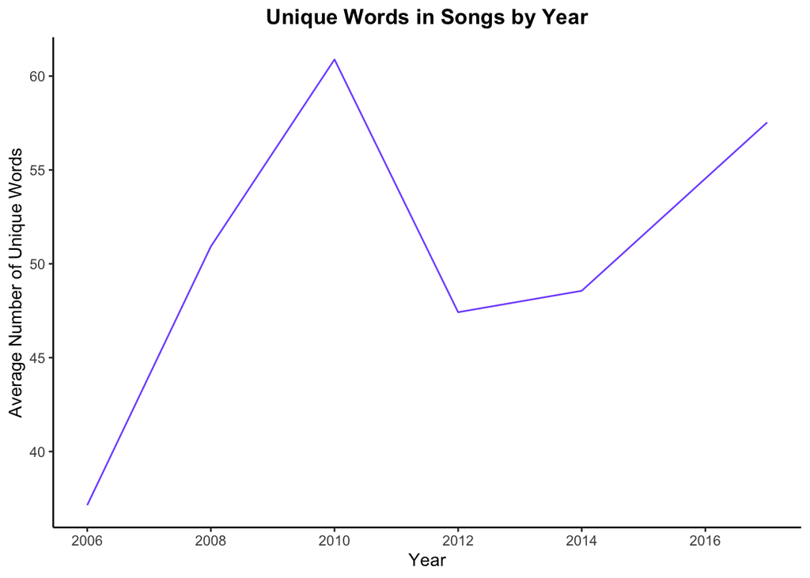

The chart above shows that Taylor reached her greatest lexical complexity in 2010, as defined as he highest average number of unique words per song. 2010 also roughly marks Taylor's transition from a country music artist to a pop artist. The most notable trend is that as Taylor's songs skewed more heavily toward the pop music genre, the number of unique words in songs decreased. But again, looking at averages doesn't get us very far, so let's take a gander at boxplots.

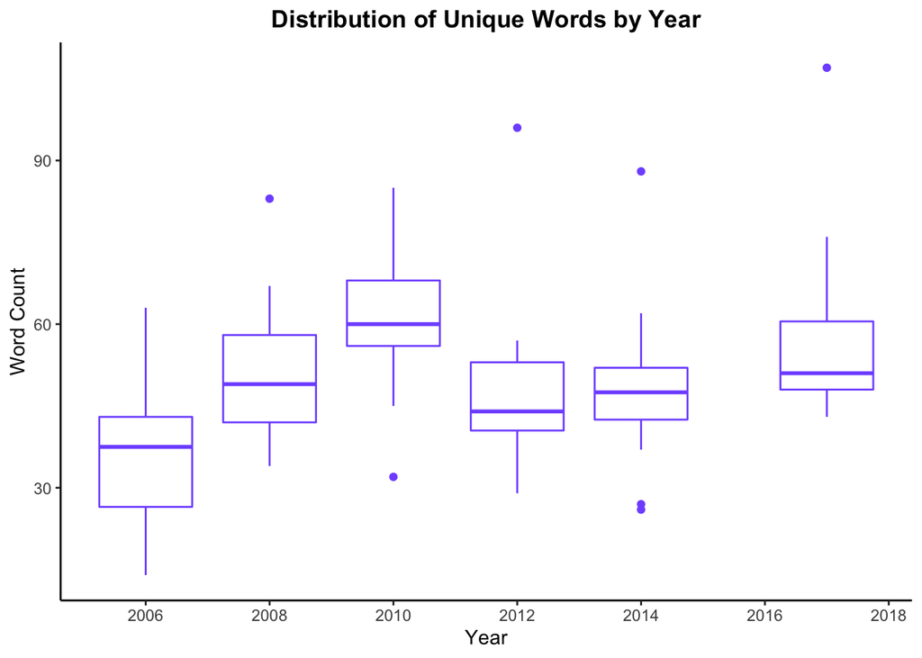

The distribution of unique words in songs is quite similar over time, but gets tighter. This visualization suggests that the songs on Taylor's albums have similar word complexity, and that word complexity has slightly increased over her past two albums.

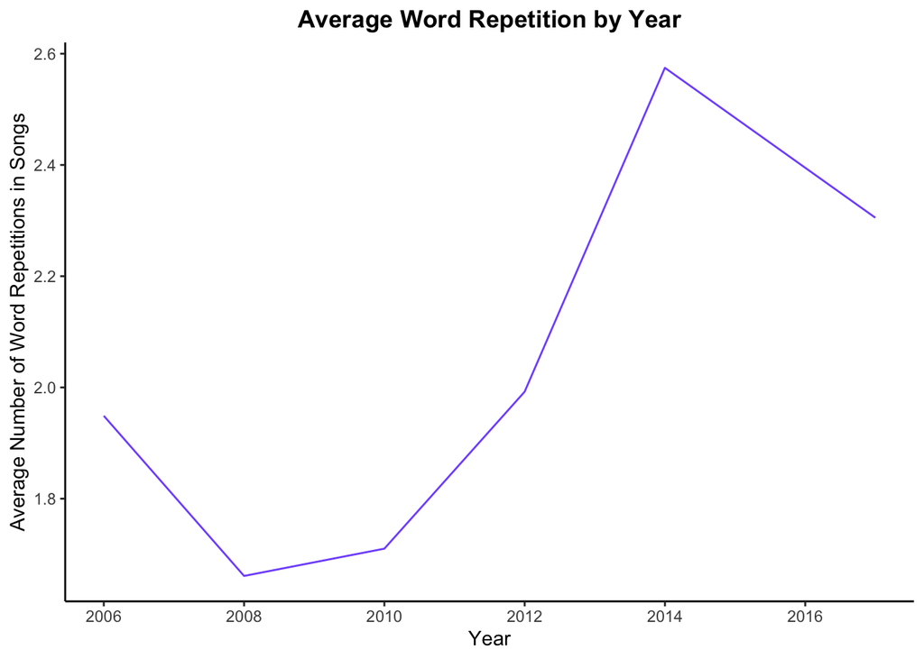

Word repetition increased dramatically after 2010, and was at its highest in 2014. In 2014, Taylor repeated words on average 2.57 times. High word repetition frequently afflicts pop songs, so I am not surprised that Taylor's songs have higher word repetition after her transition to pop music.

## Question 3: What topics are typically covered in Taylor's songs?

Does Taylor Swift really sing about the same topics, or am I salty? To find out, I use a method called [Latent Dirichlet Allocation (LDA)](https://eight2late.wordpress.com/2015/09/29/a-gentle-introduction-to-topic-modeling-using-r/). LDA is a generative probabilistic model commonly used to model topics in documents.

LDA assumes that each document is a mixture of topics, and each topic is a mixture of words. It can be used for many different types of analyses. The probabilistic model used in LDA assigns probabilities to a word falling under a given topic, and to a topic being assigned to a given document.

```
##        word   n
## 1      time 164
## 2      love 160
## 3      baby 115
## 4       ooh 103
## 5      stay  88
## 6     wanna  82
## 7     shake  80
## 8      yeah  80
## 9        ey  72
## 10    night  72
## 11     girl  66
## 12     feel  64
## 13      bad  63
## 14    gonna  62
## 15     call  60
## 16     home  60
## 17     eyes  52
## 18  dancing  51
## 19    break  49
## 20     life  47
## 21     mind  46
## 22  forever  45
## 23  waiting  45
## 24       ah  44
## 25 remember  44
```

Unusurpsingly, "love" clocks in at #2. But let's not throw Taylor under the bus here. Is it really true that all of her songs are about relationships and heartbreaks? Did she really need to reinvent herself in 2017 (and 2014, and 2012... you get the point) to escape that image?

I used LDA to generate 5 topics, and each topic groups a set of words together. The table below shows that the topics don't really describe concepts. Some of the topics seem to reference songs more than concepts; Topic 3 clearly references "Shake it Off." Topic 2 appears to cover the most romantic ground.

```
##   Topic.1 Topic.2 Topic.3 Topic.4 Topic.5
## 1   night    love     ooh    girl    feel
## 2     day    time   shake    home   wanna
## 3  rememb    stay    call     eye    yeah
## 4    babi    hand    wait   forev   light
## 5   dream     bad   gonna    hold    game
```

The last bit of analysis I want to cover is determining whether topics occur more frequently over time. Is Taylor releasing songs that fall under a given topic more frequntly? Might the topics represent an album?

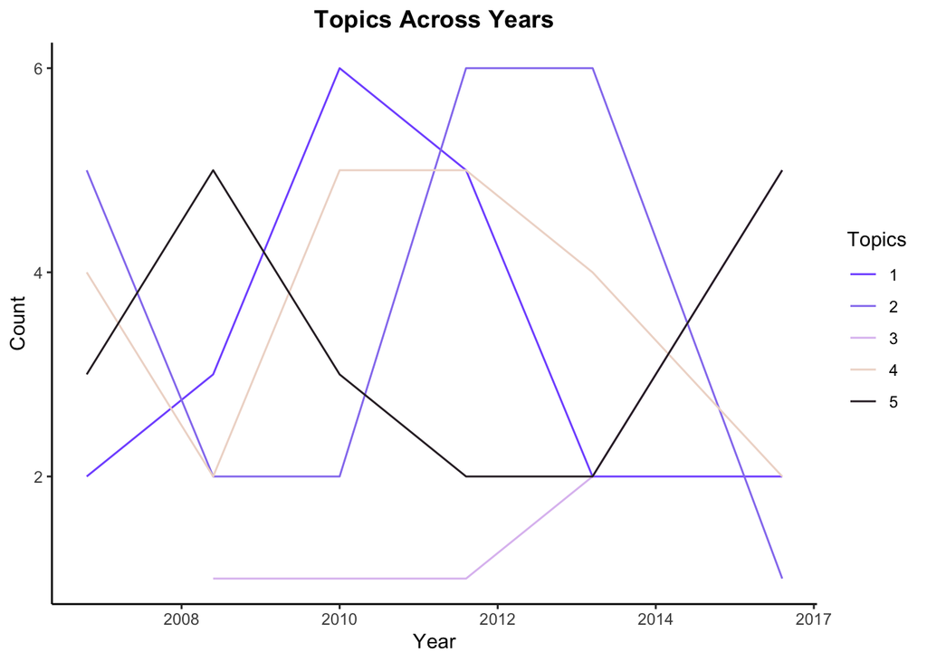

"Year" and "Topic" do not appear to be correlated at all. The data show that topics are spread out relatively evenly across years. Topic 5 seems to be very prominent across songs in 2017. Looking at the words assigned high probability to Topic 5, including "wanna," "feel," and "game," might it be the case that songs falling under that category represent a lighter tone, or a shift in the way Taylor references her agency?

The LDA analysis revealed much of what I already knew, in that the topics of Taylor Swift's songs tend to be associated with love, feelings, dreaming (of the romantic sort), etc. The exploratory analysis shows that Taylor's songs became wordier over time, but seem to suffer from the "song compression" phenomenon and aren't actually using a diversity of words.

I do feel like now I know a little more about the patterns hidden underneath some of her most popular songs, and maybe a little more about what makes them so catchy. I hope this analysis inspires you to take a deep dive into the parts of pop culture you most enjoy!